# Networks

Consider the `Minneapolis2013` election. Presumably, there is some relationship between a voter’s first and second choices. This could be visualized as a network. Each candidate is a node, edges exist between candidate pairs who were commonly selected.

Here’s an analysis that looks at the *fraction* of the ballots that contained a pair among the ballots for each first-choice candidate:

```r
PairFrac <- Minneapolis2013 %>%
  group_by( First, Second ) %>%
  summarise( ballots=n() ) %>% # remains grouped by First
  mutate( frac=ballots/sum(ballots))
```

Since there are 38 candidates, there are $38 \times 38 = 1444$ possible pairs.[^1] Such a large number of edges would be hard to see. So let’s look at the top 3 second-place choices for each candidate and winnow further by requiring that there be more than 20 ballots for the pair:

```r
Edges <-
  PairFrac %>%
  group_by( Second ) %>%
  filter( rank(desc(frac)) <= 3, ballots > 20 )
```

```r
Edges
```

[output not shown]

Each candidate will be a node in the network. But there is no natural order to the candidates that would dictate where they should be positioned in a diagram.

The `edgesToVertices()` function calculates vertex locations in a way that brings connected vertices nearby and separates unconnected vertices.

```r
Vertices <-
  edgesToVertices( Edges, from=First, to=Second )
head(Vertices)
```

```
                          ID       x       y
1 ABDUL M RAHAMAN "THE ROCK" -14.293 18.6610
2          ALICIA K. BENNETT  13.930 -3.1135
3               BETSY HODGES  -8.226 -0.6626
4                   BOB FINE  15.972  9.3680
5                 CAM WINTON  15.173 13.4785
6          CHRISTOPHER CLARK  10.682 17.7229
```

This is easy to plot out, for instance:

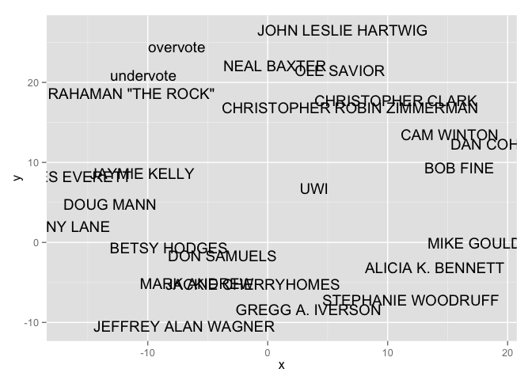

```r
Vertices %>%
  ggplot(  ) +
  geom_text( aes(label=ID, x=x, y=y))
```

Now the x, y positions of the nodes can be used to set the start and ending positions of each of the edges. To combine the information in `Vertices` with that in `Edges`, use `edgesForPlotting()`:

```r
PositionedEdges <-
  edgesForPlotting( Vertices, ID=ID, x, y, from=First, to=Second, Edges=Edges )
head( PositionedEdges)
```

```
                      Second                      First
1 ABDUL M RAHAMAN "THE ROCK" ABDUL M RAHAMAN "THE ROCK"
2               BETSY HODGES                DON SAMUELS
3               BETSY HODGES                MARK ANDREW
4               BETSY HODGES                  DOUG MANN
5                   BOB FINE                 CAM WINTON
6                   BOB FINE                  DAN COHEN
  ballots    frac       x      y    xend    yend
1      69 0.20414 -14.293 18.661 -14.293 18.6610
2    3346 0.40144  -3.762 -1.629  -8.226 -0.6626
3    6970 0.35590  -5.902 -5.138  -8.226 -0.6626
4     245 0.31451 -13.141  4.810  -8.226 -0.6626
5     597 0.07948  15.173 13.478  15.972  9.3680
6     119 0.06618  18.982 12.270  15.972  9.3680
```

`geom_segment()` lets you draw in the segments. Since the vertices and edges come from different data tables, `geom_segment()` needs to be passed the positioned edges as the `data=` argument.

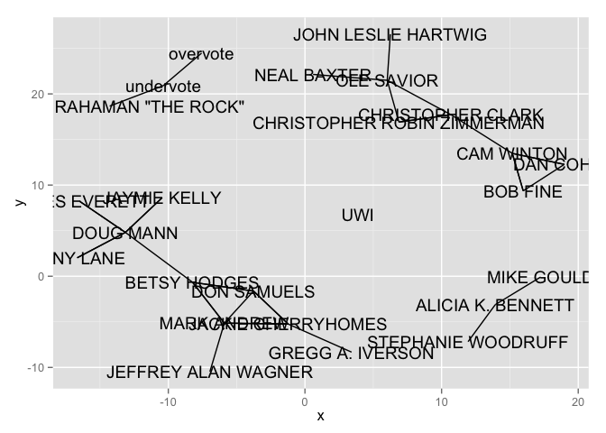

```r
Vertices %>%
  ggplot(  ) +
  geom_text( aes(label=ID, x=x, y=y)) +
  geom_segment( data=PositionedEdges,
                aes( x=x, y=y, xend=xend, yend=yend))
```

You can see that there are two major groups and a couple of minor groups. It might be informative to use color to indicate how many ballots there are in each connection and size of a dot to show the total number of votes a candidate got.

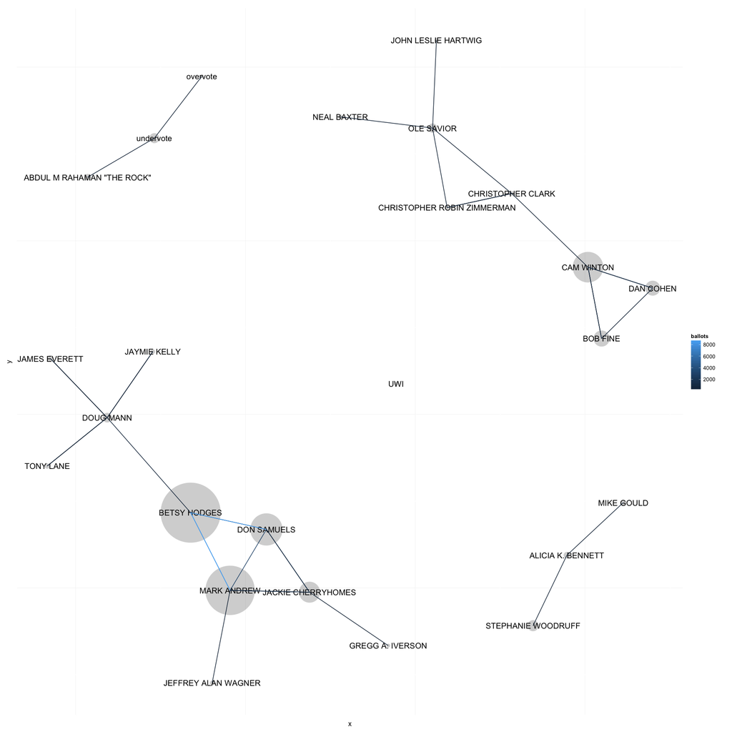

```r
Votes <-
  Minneapolis2013 %>%
  mutate( ID=First ) %>%
  group_by( ID ) %>%
  summarise( total=n() )
Vertices %>%
  inner_join( Votes ) %>%
  ggplot(  ) +
  geom_point(alpha=.2, aes( x=x, y=y, size=total ) ) +
  scale_size_area( max_size=50, guide="none" ) +
  geom_text( aes(label=ID, x=x, y=y)) +
  geom_segment( data=PositionedEdges,
                aes( x=x, y=y, xend=xend, yend=yend, color=ballots )) +
  theme(axis.ticks=element_blank(), axis.text=element_blank(), panel.background=element_blank())
```

You can see the political affiliations and other information about the candidates [here](http://en.wikipedia.org/wiki/Minneapolis_mayoral_election,_2013). Betsy Hodges, Don Samuels, Mark Andrew, and Jackie Cherryholmes are all affiliated with the DFL; Cam Winton is an independent endorsed by the Republican party.

Please use the comment system to make suggestions, point out errors, or to discuss the topic.

[comments powered by Disqus](http://disqus.com)

Written by Daniel Kaplan for the Data & Computing Fundamentals Course. Development was supported by grants from the National Science Foundation for Project Mosaic (NSF DUE-0920350) and from the Howard Hughes Medical Institute.

[^1]: Including ballots where the first- and second-place choices are the same.